# Neuroanatomy Correlates of Early Biomarkers in Alzheimer's Disease

### This notebook logistics/gradient-boosted models for predicting conversion from mild cognitive impairment (MCI) to Alzheimer's disease (AD):

**Model A** - demographics + neuroimaging only (baseline)

**Model B1** - Model A features + CSF NfL

**Model B2** - Model A features + Plasma NfL

Each model is evaluated with cross-validation ROC-AUC using both XGBoost and Logistic Regression in 5 folds and 3 folds, then interpreted with SHAP and Permutation importance.

> **Data availability:** The source data (*`mlbaseline_data_v2.csv*) is not included in this repository. It contains clinical/biomarker data derived from a restricted-access cohort(data use agreement required). See the README for details on obtaining access.

```python
import pandas as pd
import numpy as np
from sklearn.model_selection import cross_val_score, StratifiedKFold
from xgboost import XGBClassifier
from sklearn.linear_model import LogisticRegression
from sklearn.pipeline import make_pipeline
from sklearn.preprocessing import StandardScaler
import shap
from sklearn.inspection import permutation_importance
import matplotlib.pyplot as plt
```

```python
#Data_loading
df= pd.read_csv("ml_baseline_data_v2.csv")
```

```python
df.tail(1)
```

|  | RID | DX_bl | EC_bilateral | HIPP_total | CSF_PTAU_bl | CSF_TAU_bl | CSF_A4240_bl | pT217_bl | AB4240_bl | CSF_NfL_bl | Plasma_NfL_Q_bl | AGE | SEX_num | PTEDUCAT | APOE4_num | converted | max_followup |
| --- | --- | --- | --- | --- | --- | --- | --- | --- | --- | --- | --- | --- | --- | --- | --- | --- | --- |
| 216 | 1301 | CN | 3.145 | 7506 | NaN | NaN | NaN | NaN | NaN | NaN | NaN | 72.1 | 1 | 18 | 2 | 0 | 3.008898 |

```python
#check_missing_values (Quality_checks)
print("---Missing Values---")
print(df.isnull().sum())
```

```
---Missing Values---
RID                  0
DX_bl                0
EC_bilateral         0
HIPP_total           0
CSF_PTAU_bl        205
CSF_TAU_bl         205
CSF_A4240_bl       205
pT217_bl           205
AB4240_bl          205
CSF_NfL_bl         108
Plasma_NfL_Q_bl    131
AGE                  0
SEX_num              0
PTEDUCAT             0
APOE4_num            0
converted            0
max_followup         0
dtype: int64
```

```python
#To_print_the_proportional_distribution(Percentages)_of_values_in_the_"Converted"_column
print(df['converted'].value_counts(normalize=True))
```

```
converted
0    0.898618
1    0.101382
Name: proportion, dtype: float64
```

```python
#define_feature_sets. The_will_be_used_for_the_Model_A,Model_B1_and_Model_B2.
demo_neuro_cols = ['EC_bilateral', 'HIPP_total', 'AGE', 'SEX_num', 'PTEDUCAT', 'APOE4_num']
Target_col = 'converted'
A_biomarkers_cols= ['CSF_NfL_bl']
B_biomarkers_cols= ['Plasma_NfL_Q_bl']
```

```python
#to_clean_data_for_models_A(drop_rows_missing_core_features)
#Note_how_(demo_neuro_cols)_was_used_for_model_a_below.
df_model_a= df.dropna(subset=demo_neuro_cols + [Target_col])

x_a= df_model_a[demo_neuro_cols]
y_a= df_model_a[Target_col]

#model_and_cross_validation
model_a= XGBClassifier(random_state=42, eval_metric='logloss')
cv= StratifiedKFold(n_splits=5, shuffle=True, random_state=42)
scores_a= cross_val_score(model_a, x_a, y_a, cv=cv, scoring='roc_auc')
print(f"Model A Mean AUC: {scores_a.mean():.3f} (+/-{scores_a.std():.3f})")
```

```
Model A Mean AUC: 0.618 (+/-0.104)
```

# Model B -- Addition of biomarkers (CSF_NfL_bl and Plasma_NfL_Q_bl)

```python
#to_check_if_biomakers_have_enough_participants(>= 30 non-null)_for_the_first_model_B(Model_B1)
df_model_b1= df.dropna(subset=demo_neuro_cols + A_biomarkers_cols + [Target_col])

print(f"Model B1 Sample Size: {len(df_model_b1)}")
print("Conversion Distribution:\n", df_model_b1[Target_col].value_counts())

if len(df_model_b1)>= 30 and df_model_b1[Target_col].sum() >= 10:
    x_b1= df_model_b1[demo_neuro_cols + A_biomarkers_cols]
    y_b1= df_model_b1[Target_col]
    model_b1= XGBClassifier(random_state=42)
    scores_b1= cross_val_score(model_b1, x_b1, y_b1, cv=cv, scoring='roc_auc')
    print(f"Model B1 Mean AUC: {scores_b1.mean():.3f} (+/-{scores_b1.std():.3f})")
else:
    print("Skipping Model B: Sample Size criteria not met.")
```

```
Model B1 Sample Size: 109
Conversion Distribution:
 converted
0    98
1    11
Name: count, dtype: int64
Model B1 Mean AUC: 0.619 (+/-0.170)
```

```python
#to_check_if_biomakers_have_enough_participants(>= 30 non-null)_for_the_second_model_B(Model_B2)
df_model_b2= df.dropna(subset=demo_neuro_cols + B_biomarkers_cols + [Target_col])

print(f"Model B2 Sample Size: {len(df_model_b2)}")
print("Conversion Distribution:\n", df_model_b2[Target_col].value_counts())

if len(df_model_b2)>= 30 and df_model_b2[Target_col].sum() >= 10:
    x_b2= df_model_b2[demo_neuro_cols + B_biomarkers_cols]
    y_b2= df_model_b2[Target_col]
    model_b2= XGBClassifier(random_state=42)
    scores_b2= cross_val_score(model_b2, x_b2, y_b2, cv=cv, scoring='roc_auc')
    print(f"Model B2 Mean AUC: {scores_b2.mean():.3f} (+/-{scores_b2.std():.3f})")
else:
    print("Skipping Model B: Sample Size criteria not met.")
```

```
Model B2 Sample Size: 86
Conversion Distribution:
 converted
0    65
1    21
Name: count, dtype: int64
Model B2 Mean AUC: 0.463 (+/-0.066)
```

##### *Five folds cross-validation was intially employed; however, following observation from of the result above and a relatively smaller sample size in both B models, three-fold cross-validation was considered to ensure that each fold retained a sufficient number of observations for model training and validation. Note that this change was not applied on model A as available sample size was considered adequate to support the continued use of five-fold. Regardless three-folds will be applied on Model A in the later stages to note any improvment observed.*

```python
#define_3_folds
#this_is_to_observe_if_we_will_have_a_better_result
cv_3folds= StratifiedKFold(n_splits=3, shuffle=True, random_state=42)
```

```python
#Running_the_B1(CSF)_biomarker_on_3_folds_instead_of_5_folds_as_seen_above.
#The_difference_is_that_instead_of_"cv"_which_was_defined_earlier_we_now_use_"cv_3folds"_which_was_defined_above_this_cell
#as_shown_in_cross_val_score_below
#will_also_do_the_same_for_B2_on_the_next_cell.
A_biomarkers_cols= ['CSF_NfL_bl']
df_model_b1= df.dropna(subset=demo_neuro_cols + A_biomarkers_cols + [Target_col])

print(f"Model B1 Sample Size: {len(df_model_b1)}")
print("Conversion Distribution:\n", df_model_b1[Target_col].value_counts())

if len(df_model_b1)>= 30 and df_model_b1[Target_col].sum() >= 10:
    x_b1= df_model_b1[demo_neuro_cols + A_biomarkers_cols]
    y_b1= df_model_b1[Target_col]
    model_b1= XGBClassifier(random_state=42)
    scores_b1= cross_val_score(model_b1, x_b1, y_b1, cv=cv_3folds, scoring='roc_auc')
    print(f"Model B1 Mean AUC: {scores_b1.mean():.3f} (+/-{scores_b1.std():.3f})")
else:
    print("Skipping Model B: Sample Size criteria not met.")
```

```
Model B1 Sample Size: 109
Conversion Distribution:
 converted
0    98
1    11
Name: count, dtype: int64
Model B1 Mean AUC: 0.672 (+/-0.009)
```

```python
#Running_the_B2(Plasma)_biomarker_on_3_folds_instead_of_5_folds_as_seen_above.
B_biomarkers_cols= ['Plasma_NfL_Q_bl']
df_model_b2= df.dropna(subset=demo_neuro_cols + B_biomarkers_cols + [Target_col])

print(f"Model B2 Sample Size: {len(df_model_b2)}")
print("Conversion Distribution:\n", df_model_b2[Target_col].value_counts())

if len(df_model_b2)>= 30 and df_model_b2[Target_col].sum() >= 10:
    x_b2= df_model_b2[demo_neuro_cols + B_biomarkers_cols]
    y_b2= df_model_b2[Target_col]
    model_b2= XGBClassifier(random_state=42)
    scores_b2= cross_val_score(model_b2, x_b2, y_b2, cv=cv_3folds, scoring='roc_auc')
    print(f"Model B2 Mean AUC: {scores_b2.mean():.3f} (+/-{scores_b2.std():.3f})")
else:
    print("Skipping Model B: Sample Size criteria not met.")
```

```
Model B2 Sample Size: 86
Conversion Distribution:
 converted
0    65
1    21
Name: count, dtype: int64
Model B2 Mean AUC: 0.538 (+/-0.053)
```

#### *After using three-folds for our B models (model B1 and model B2), we are using Logistics regression to determine whether XGBoost performance is comming from genuine signal or from it noise sensitivity nature. Starting with model A.*

```python
#to_test_logistic_Regression_for_Model_A
#pipeline: scales_features_first,then_runs_logistic_regression_with_class_reweighting
lr_pipeline= make_pipeline(StandardScaler(), LogisticRegression(class_weight="balanced", random_state=42), )
scores_a_lr= cross_val_score(lr_pipeline, x_a, y_a, cv=cv, scoring='roc_auc')
print(f"Model A(Logistics Regression) Mean AUC: {scores_a_lr.mean():.3f} (+/-{scores_a_lr.std():.3f})")
```

```
Model A(Logistics Regression) Mean AUC: 0.649 (+/-0.106)
```

```python
#to_test_logistic_Regression_for_B1_and_B2.

#test_model_B1(CSF)_with_Logistics_Regression
#created_a_variable(scores_b1_lr)_using_x_b1_and_y_b1_from_the_codes_above
scores_b1_lr= cross_val_score(lr_pipeline, x_b1, y_b1, cv=cv_3folds, scoring='roc_auc')

#test_model_B2(Plasma)_with_Logistic_Regression
#created_a_variable(scores_b1_lr)_using_x_b2_and_y_b2_from_the_codes_above
scores_b2_lr= cross_val_score(lr_pipeline, x_b2, y_b2, cv=cv_3folds, scoring='roc_auc')
print(
    f"Model B1(Logistic Regression) Mean AUC: {scores_b1_lr.mean():.3f} (+/- {scores_b1_lr.std():.3f})")
print(
    f"Model B2(Logistic Regression) Mean AUC: {scores_b2_lr.mean():.3f} (+/- {scores_b2_lr.std():.3f})")
```

```
Model B1(Logistic Regression) Mean AUC: 0.702 (+/- 0.073)
Model B2(Logistic Regression) Mean AUC: 0.683 (+/- 0.048)
```

#### *Bonus -- Showing model A on three-folds*

```python
#running_model_A_on_3_folds
scores_a= cross_val_score(model_a, x_a, y_a, cv=cv_3folds, scoring='roc_auc')
print(f"Model A Mean AUC: {scores_a.mean():.3f} (+/-{scores_a.std():.3f})")
```

```
Model A Mean AUC: 0.530 (+/-0.108)
```

## Explainability (SHAP AND PERMUTATION IMPORTANCE)

SHAP AND PERMUTATION IMPORTANCE are used as the explainability method across all three models. Five-folds model A result is used here while three-folds is used for both model B1 and model B2 as explained above.

# SHAP

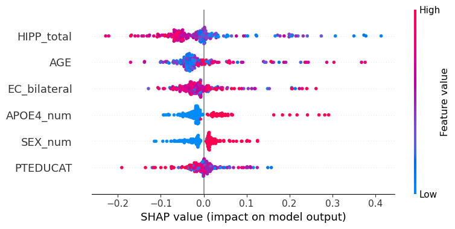

```python
 #Train_best_model_on_full_Model_A_dataset
model_a.fit(x_a, y_a)

#pass_predict_proba_as_a_callable
explainer= shap.Explainer(model_a.predict_proba, x_a)
shap_values= explainer(x_a)

#for_binary_classification_probability_output
if len(shap_values.shape) == 3:
    shap_values= shap_values[:, :, 1]

#plot_Importance
shap.summary_plot(shap_values, x_a)
```

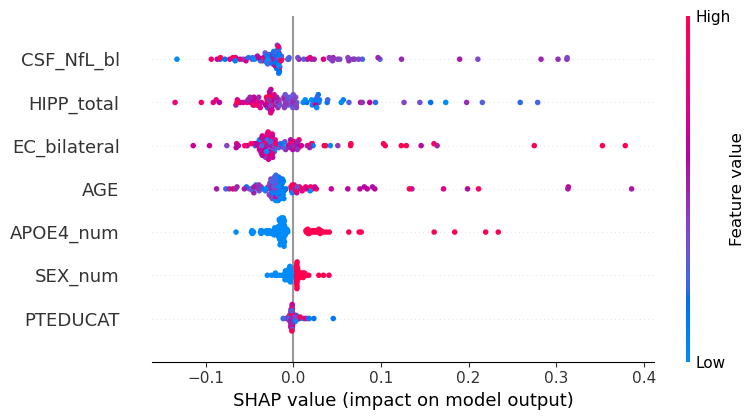

```python
#Train_best_model_on_full_Model_B1_dataset
model_b1.fit(x_b1, y_b1)

#pass_predict_proba_as_a_callable
explainer= shap.Explainer(model_b1.predict_proba, x_b1)
shap_values= explainer(x_b1)

#for_binary_classification_probability_output
if len(shap_values.shape) == 3:
    shap_values= shap_values[:, :, 1]

#plot_Importance
shap.summary_plot(shap_values, x_b1)
```

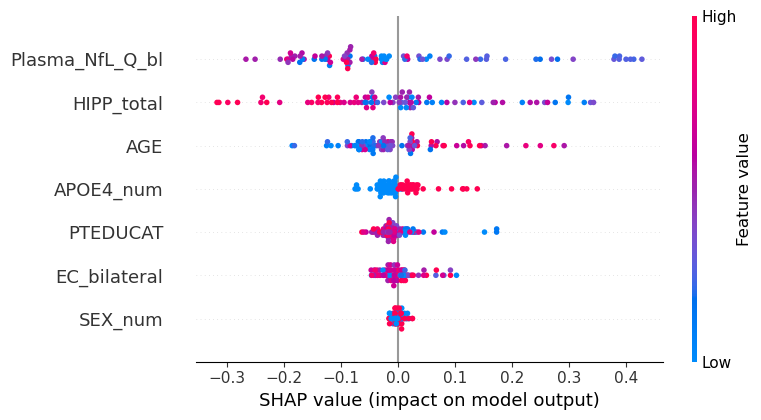

```python
#Train_best_model_on_full_Model_B2_dataset
model_b2.fit(x_b2, y_b2)

#pass_predict_proba_as_a_callable
explainer= shap.Explainer(model_b2.predict_proba, x_b2)
shap_values= explainer(x_b2)

#for_binary_classification_probability_output
if len(shap_values.shape) == 3:
    shap_values= shap_values[:, :, 1]

#plot_Importance
shap.summary_plot(shap_values, x_b2)
```

# PERMUTATION IMPORTANCE

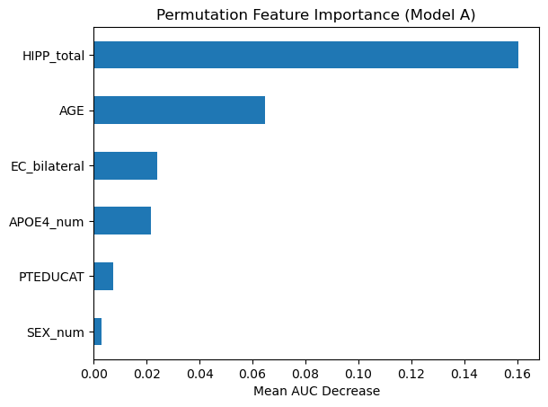

```python
#fitting_the_model
model_a.fit(x_a, y_a)

#calculate_permutation_importance_on_the_fitted_model
Result= permutation_importance(model_a, x_a, y_a, n_repeats=10, random_state=42, scoring='roc_auc')

#arrange_into_a_series
perm_importance= pd.Series(Result.importances_mean, index= x_a.columns).sort_values(ascending=True)

#Plot
perm_importance.plot(kind='barh', title='Permutation Feature Importance (Model A)')
plt.xlabel('Mean AUC Decrease')
plt.show()
```

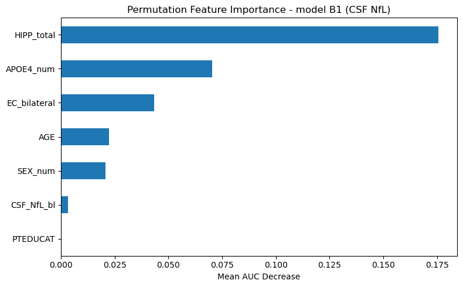

```python
#fitting_model_B1
lr_pipeline.fit(x_b1, y_b1)

#calculate_permutation_importance
result_b1= permutation_importance(lr_pipeline, x_b1, y_b1, n_repeats=10, random_state=42, scoring="roc_auc")

#Create_series_and_sort_values
perm_importance_b1=pd.Series(result_b1.importances_mean, index=x_b1.columns).sort_values(ascending=True)

#plot_reults
plt.figure(figsize=(8, 5))
perm_importance_b1.plot(kind="barh", title="Permutation Feature Importance - model B1 (CSF NfL)")
plt.xlabel("Mean AUC Decrease")
plt.tight_layout()
plt.show()
```

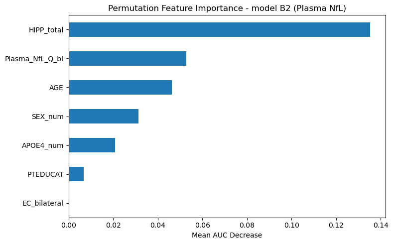

```python
#fitting_model_B2
lr_pipeline.fit(x_b2, y_b2)

#calculate_permutation_importance
result_b2= permutation_importance(lr_pipeline, x_b2, y_b2, n_repeats=10, random_state=42, scoring="roc_auc")

#Create_series_and_sort_values
perm_importance_b2=pd.Series(result_b2.importances_mean, index=x_b2.columns).sort_values(ascending=True)

#plot_reults
plt.figure(figsize=(8, 5))
perm_importance_b2.plot(kind="barh", title="Permutation Feature Importance - model B2 (Plasma NfL)")
plt.xlabel("Mean AUC Decrease")
plt.tight_layout()
plt.show()
```